HOME › TEACHING › EXPERIMENTAL DESIGN › **T-TEST CLASS EXAMPLE**

# T-test Class Example.

# Permutations Tests

Permutation tests allows us to perform tests with basically no assumptions.

Read in my data

```r
dat <- read.csv("data/t_test_data.csv")
```

Lets test whether control and treatment have different range widths

```r
cont.range <- range(dat$value[dat$group=="Control"])
trt.range <- range(dat$value[dat$group=="Treatment"])

obs.dif <- (cont.range[2] - cont.range[1]) - (trt.range[2] - trt.range[1])
```

This shows that the observed difference in our ranges was: -0.85.

Now lets create a null distribution

```r
tempdat <- dat
null.dist<-c()
for(i in 1:1000){
  tempdat$group <- sample(tempdat$group, 58)
  cont.range <- range(tempdat$value[tempdat$group=="Control"])
  trt.range <- range(tempdat$value[tempdat$group=="Treatment"])
  null.dist[i] <- (cont.range[2] - cont.range[1]) - (trt.range[2] - trt.range[1])

}
```

now lets plot our null and the observed value

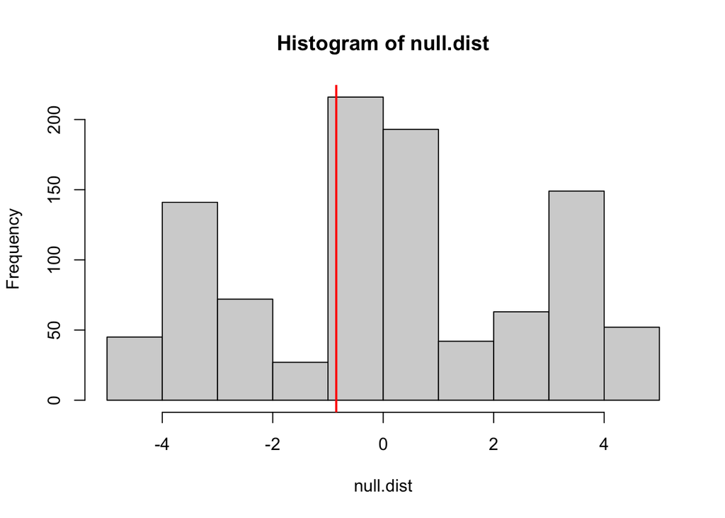

```r
hist(null.dist)
abline(v=obs.dif, lwd=2, col="red")
```

Whats the p-value?

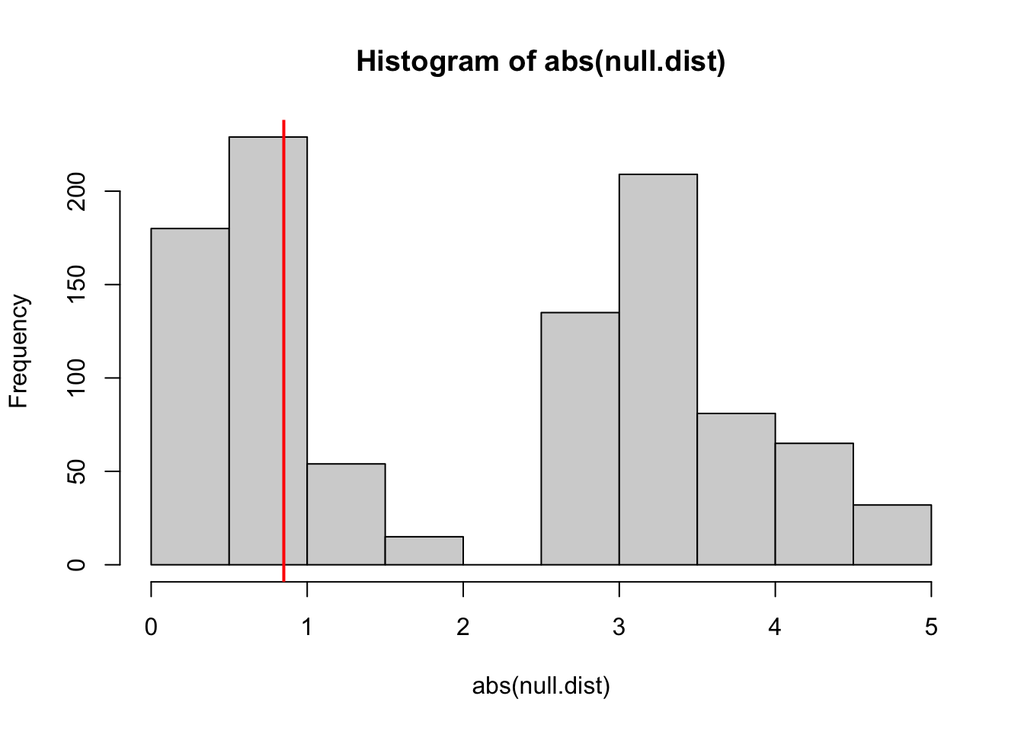

```r
hist(abs(null.dist))
abline(v=abs(obs.dif),lwd=2,col="red")
```

```r
pval <- sum(null.dist>=obs.dif)/1000
```

This shows that my pvalue is 0.702. Be able to describe what that p-value means.

Review this file and the rmd version of it to see what I did. Continue to play and practive with RMD files prior to next week.